# Lecture 19 - More on Time Series

```python
import pandas as pd
import numpy as np
import matplotlib.pyplot as plt
```

```python
# load in data
df_financial = pd.read_csv("data_raw/financial.csv")

# convert to datetime format
df_financial["date"] = pd.to_datetime(df_financial["date_str"])
```

# I. Date Formatting

Convert to string (a)

- A format code `%` is used to denote date formats
- Useful when working with text data

$\quad$

[figure not shown]

- Can access the `.strftime()` (string format time) method for the "date" column as follows:

```python
print(type(df_financial["date"]))
print(type(df_financial["date"].dt)) # .DatetimeProperties methods/attributes
print(type(type(df_financial["date"].dt.strftime))) # a "type" (i.e. "class")

# works like a function
display(df_financial["date"].dt.strftime("%d"))
```

```
<class 'pandas.core.series.Series'>
<class 'pandas.core.indexes.accessors.DatetimeProperties'>
<class 'type'>
```

```
0       04
1       05
2       06
3       09
4       10
        ..
1300    29
1301    30
1302    31
1303    03
1304    04
Name: date, Length: 1305, dtype: object
```

Let's add two columns:

- One called "month_str" which indicates what month the data in the row was taken from
- One called "week_str" which indicates what week the data in the row was taken from (roughly 52 weeks per year)

```python
df_financial["month_str"] = df_financial["date"].dt.strftime("%m")
df_financial["week_str"]  = df_financial["date"].dt.strftime("%W")
```

Convert to string (b)

$\quad$

[figure not shown]

```python
df_financial["monthname"]   =  df_financial["date"].dt.strftime("%B")
df_financial["weekdayname"] =  df_financial["date"].dt.strftime("%A")
```

Using format codes within other strings

```python
# Insert format codes inside custom strings
# Internally it will "fill-in-the-blank" with the corresponding information
# You can use commas, dashes (--), slash (/) or other characters

message_monthname =  df_financial["date"].dt.strftime("This is the month of %B")

message_monthday  =  df_financial["date"].dt.strftime("The day of the week is %A")

message_yearmonth =  df_financial["date"].dt.strftime("%Y-%m")


print(message_monthname)
print(message_monthday)
print(message_yearmonth)
```

```
0       This is the month of April
1       This is the month of April
2       This is the month of April
3       This is the month of April
4       This is the month of April
                   ...
1300    This is the month of March
1301    This is the month of March
1302    This is the month of March
1303    This is the month of April
1304    This is the month of April
Name: date, Length: 1305, dtype: object
0       The day of the week is Wednesday
1        The day of the week is Thursday
2          The day of the week is Friday
```

[output cut: 21 more lines]

**Exercise:**

- Create a new column called "date_test"  
  which has the format using `.dt.strftime()`

$\quad$ `Monday, December 31, 2023`

```python
# Write your own code

date_test = df_financial["date"].dt.strftime("%A, %B %d, %Y")

date_test
```

```
0       Wednesday, April 04, 2018
1        Thursday, April 05, 2018
2          Friday, April 06, 2018
3          Monday, April 09, 2018
4         Tuesday, April 10, 2018
                  ...
1300    Wednesday, March 29, 2023
1301     Thursday, March 30, 2023
1302       Friday, March 31, 2023
1303       Monday, April 03, 2023
1304      Tuesday, April 04, 2023
Name: date, Length: 1305, dtype: object
```

```python
# Combine format codes + characters depending on the input
# Can include spaces, commas, "/", "-" or any other formatting
# Be careful to include the format code letters in upper or lower case
# depending on the intended format


df_financial['date_ex1_dt'] = pd.to_datetime(df_financial["date_ex1"], format = "%B %d %Y")
df_financial['date_ex2_dt'] = pd.to_datetime(df_financial["date_ex2"], format = "%A, %Y-%m-%d")
```

**Exercise:**

- Practice `pd.to_datetime()`
- Parse the column "data_ex3"
- Take a close look at the formatting

HINT: Refer to the table of format codes  
in the previous section

```python
# your code here
df_financial['date_ex3_dt'] = pd.to_datetime(df_financial["date_ex3"], format = "%d-%b-%y")
```

# II. Grouping

```python
# In "freq" specify the letter for the level of aggregation
# There are also more advanced options!
# See https://pandas.pydata.org/pandas-docs/stable/user_guide/timeseries.html#offset-aliases

month_config = pd.Grouper(key='date', freq='ME')

print(month_config)
type(month_config)
```

```
TimeGrouper(key='date', freq=<MonthEnd>, axis=0, sort=True, dropna=True, closed='right', label='right', how='mean', convention='e', origin='start_day')
```

```
pandas.core.resample.TimeGrouper
```

See the [Pandas Documentation](https://pandas.pydata.org/pandas-docs/stable/user_guide/timeseries.html#offset-aliases) for a list of strings that can be used for the "freq" argument

```python
# Group on the period column
# We use a wrapper () to split the command into multiple lines
# The ".reset_index()" option ensures that the grouper is
# converted to a column. This is important for plotting.
# There's a lot of options too

monthlydata = (df_financial
               .groupby(month_config)
               .agg(sp500_mean = ("sp500","mean"))
               .reset_index())


display(monthlydata)
```

|  | date | sp500_mean |
| --- | --- | --- |
| 0 | 2018-04-30 | 2659.463158 |
| 1 | 2018-05-31 | 2701.493636 |
| 2 | 2018-06-30 | 2754.352857 |
| 3 | 2018-07-31 | 2793.643333 |
| 4 | 2018-08-31 | 2857.820435 |
| ... | ... | ... |
| 56 | 2022-12-31 | 3912.380952 |
| 57 | 2023-01-31 | 3960.656500 |
| 58 | 2023-02-28 | 4079.684737 |
| 59 | 2023-03-31 | 3968.559130 |
| 60 | 2023-04-30 | 4112.555000 |

61 rows × 2 columns

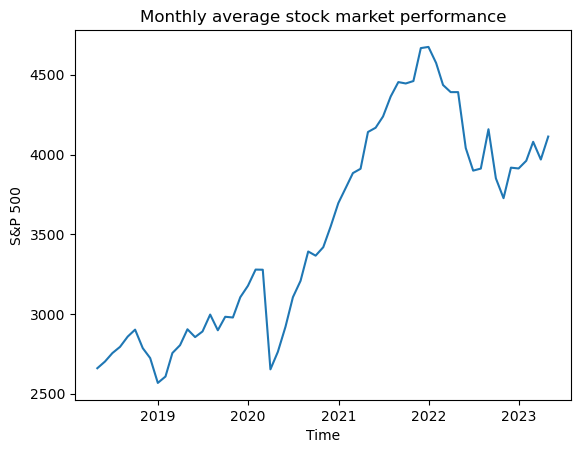

```python
plt.plot("date","sp500_mean",
          data = monthlydata)
plt.xlabel("Time")
plt.ylabel("S&P 500")
plt.title("Monthly average stock market performance")
plt.show()
```

**Exercise:**

- Compute an aggregate dataset which computes the standard  
  deviation of the S&P 500 at the **weekly** level.
- Generate a line plot with your results

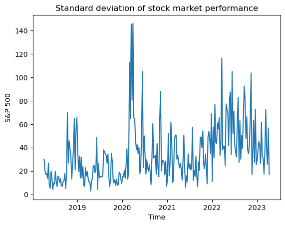

```python
# your code here

week_config = pd.Grouper(key='date', freq='W')

weeklydata = (df_financial
               .groupby(week_config)
               .agg(sp500_std = ("sp500","std"))
               .reset_index())

plt.plot("date","sp500_std",
          data = weeklydata)
plt.xlabel("Time")
plt.ylabel("S&P 500")
plt.title("Standard deviation of stock market performance")
plt.show()
```

# III. Pivoting/Melting

Wide and long format

Data can come in a wide variety of formats

- Few rows, multiple columns (wide)
- Stacked rows, few columns (long)
- The **information** is the same!

Wide to long

$\quad$

[figure not shown]

```python
display(df_financial)
```

|  | date_str | sp500 | djia | date_ex1 | date_ex2 | date_ex3 | date | month_str | week_str | monthname | weekdayname | date_ex1_dt | date_ex2_dt | date_ex3_dt |
| --- | --- | --- | --- | --- | --- | --- | --- | --- | --- | --- | --- | --- | --- | --- |
| 0 | 4/4/2018 | 2644.69 | 24264.30 | April 04 2018 | Wednesday, 2018-04-04 | 4-Apr-18 | 2018-04-04 | 04 | 14 | April | Wednesday | 2018-04-04 | 2018-04-04 | 2018-04-04 |
| 1 | 4/5/2018 | 2662.84 | 24505.22 | April 05 2018 | Thursday, 2018-04-05 | 5-Apr-18 | 2018-04-05 | 04 | 14 | April | Thursday | 2018-04-05 | 2018-04-05 | 2018-04-05 |
| 2 | 4/6/2018 | 2604.47 | 23932.76 | April 06 2018 | Friday, 2018-04-06 | 6-Apr-18 | 2018-04-06 | 04 | 14 | April | Friday | 2018-04-06 | 2018-04-06 | 2018-04-06 |
| 3 | 4/9/2018 | 2613.16 | 23979.10 | April 09 2018 | Monday, 2018-04-09 | 9-Apr-18 | 2018-04-09 | 04 | 15 | April | Monday | 2018-04-09 | 2018-04-09 | 2018-04-09 |
| 4 | 4/10/2018 | 2656.87 | 24408.00 | April 10 2018 | Tuesday, 2018-04-10 | 10-Apr-18 | 2018-04-10 | 04 | 15 | April | Tuesday | 2018-04-10 | 2018-04-10 | 2018-04-10 |
| ... | ... | ... | ... | ... | ... | ... | ... | ... | ... | ... | ... | ... | ... | ... |
| 1300 | 3/29/2023 | 4027.81 | 32717.60 | March 29 2023 | Wednesday, 2023-03-29 | 29-Mar-23 | 2023-03-29 | 03 | 13 | March | Wednesday | 2023-03-29 | 2023-03-29 | 2023-03-29 |
| 1301 | 3/30/2023 | 4050.83 | 32859.03 | March 30 2023 | Thursday, 2023-03-30 | 30-Mar-23 | 2023-03-30 | 03 | 13 | March | Thursday | 2023-03-30 | 2023-03-30 | 2023-03-30 |
| 1302 | 3/31/2023 | 4109.31 | 33274.15 | March 31 2023 | Friday, 2023-03-31 | 31-Mar-23 | 2023-03-31 | 03 | 13 | March | Friday | 2023-03-31 | 2023-03-31 | 2023-03-31 |
| 1303 | 4/3/2023 | 4124.51 | 33601.15 | April 03 2023 | Monday, 2023-04-03 | 3-Apr-23 | 2023-04-03 | 04 | 14 | April | Monday | 2023-04-03 | 2023-04-03 | 2023-04-03 |
| 1304 | 4/4/2023 | 4100.60 | 33402.38 | April 04 2023 | Tuesday, 2023-04-04 | 4-Apr-23 | 2023-04-04 | 04 | 14 | April | Tuesday | 2023-04-04 | 2023-04-04 | 2023-04-04 |

1305 rows × 14 columns

```python
financial_long = pd.melt(df_financial,
                         var_name = "portfolio_type",
                         value_name = "portfolio_value",

                         id_vars='date',
                         value_vars=['sp500','djia'])
```

```python
display(financial_long)
print()
display(financial_long.sort_values(by = "date"))
```

|  | date | portfolio_type | portfolio_value |
| --- | --- | --- | --- |
| 0 | 2018-04-04 | sp500 | 2644.69 |
| 1 | 2018-04-05 | sp500 | 2662.84 |
| 2 | 2018-04-06 | sp500 | 2604.47 |
| 3 | 2018-04-09 | sp500 | 2613.16 |
| 4 | 2018-04-10 | sp500 | 2656.87 |
| ... | ... | ... | ... |
| 2605 | 2023-03-29 | djia | 32717.60 |
| 2606 | 2023-03-30 | djia | 32859.03 |
| 2607 | 2023-03-31 | djia | 33274.15 |
| 2608 | 2023-04-03 | djia | 33601.15 |
| 2609 | 2023-04-04 | djia | 33402.38 |

2610 rows × 3 columns

|  | date | portfolio_type | portfolio_value |
| --- | --- | --- | --- |
| 0 | 2018-04-04 | sp500 | 2644.69 |
| 1305 | 2018-04-04 | djia | 24264.30 |
| 1306 | 2018-04-05 | djia | 24505.22 |
| 1 | 2018-04-05 | sp500 | 2662.84 |
| 2 | 2018-04-06 | sp500 | 2604.47 |
| ... | ... | ... | ... |
| 1302 | 2023-03-31 | sp500 | 4109.31 |
| 2608 | 2023-04-03 | djia | 33601.15 |
| 1303 | 2023-04-03 | sp500 | 4124.51 |
| 1304 | 2023-04-04 | sp500 | 4100.60 |
| 2609 | 2023-04-04 | djia | 33402.38 |

2610 rows × 3 columns

```python
df_means = financial_long.groupby("portfolio_type")["portfolio_value"].mean()


display(df_means)


df_means2 = df_financial[["sp500", "djia"]].mean()
display(df_means2)
```

```
portfolio_type
djia     29464.149206
sp500     3513.889397
Name: portfolio_value, dtype: float64
```

```
sp500     3513.889397
djia     29464.149206
dtype: float64
```

What's the point?

Imagine we had a DataFrame containing the following market indexes:

- S&P 500
- Dow Jones Industrial Average
- Nasdaq Composite
- DAX PERFORMANCE-INDEX
- FTSE 100 Index
- CAC 40
- Nikkei 225
- Hang Seng Index
- Brazil Stock Exchange Index
- MOEX Russia Index

Here's how we would compute the average of each index for (a) wide format, and (b) long format

```python
# Hypothetical situation.
# These dataframes don't exist, so we won't run this code
run_cell = False

if run_cell:
    # wide format
    df_hypothetical[["sp500", "djia", "nasdaq", "DAX-perf", "FTSE",
    "CAC40", "Nikkei", "Hang_Seng", "Brazil_SE", "MOEX_Russia"]].mean()

    # after converting to long format
    hypothetical_long.groupby("portfolio_type")["portfolio_value"].mean()
```

Long to wide

$\quad$

[figure not shown]

```python
display(financial_long)
```

|  | date | portfolio_type | portfolio_value |
| --- | --- | --- | --- |
| 0 | 2018-04-04 | sp500 | 2644.69 |
| 1 | 2018-04-05 | sp500 | 2662.84 |
| 2 | 2018-04-06 | sp500 | 2604.47 |
| 3 | 2018-04-09 | sp500 | 2613.16 |
| 4 | 2018-04-10 | sp500 | 2656.87 |
| ... | ... | ... | ... |
| 2605 | 2023-03-29 | djia | 32717.60 |
| 2606 | 2023-03-30 | djia | 32859.03 |
| 2607 | 2023-03-31 | djia | 33274.15 |
| 2608 | 2023-04-03 | djia | 33601.15 |
| 2609 | 2023-04-04 | djia | 33402.38 |

2610 rows × 3 columns

```python
financial_wide = (pd.pivot(financial_long,
                           index = 'date',
                           columns = 'portfolio_type',
                           values =  'portfolio_value'))

# If you also want the index to be part of the dataset add
# ".reset_index()" to the end of the previous command

display(financial_wide)
```

| portfolio_type date | djia | sp500 |
| --- | --- | --- |
| 2018-04-04 | 24264.30 | 2644.69 |
| 2018-04-05 | 24505.22 | 2662.84 |
| 2018-04-06 | 23932.76 | 2604.47 |
| 2018-04-09 | 23979.10 | 2613.16 |
| 2018-04-10 | 24408.00 | 2656.87 |
| ... | ... | ... |
| 2023-03-29 | 32717.60 | 4027.81 |
| 2023-03-30 | 32859.03 | 4050.83 |
| 2023-03-31 | 33274.15 | 4109.31 |
| 2023-04-03 | 33601.15 | 4124.51 |
| 2023-04-04 | 33402.38 | 4100.60 |

1305 rows × 2 columns

**Exercise:**

In the cell below, we'll add the "percentage growth" columns from Lecture 18.

- Convert the "growth_sp500" and "growth_djia" to long format using `.melt()`
- Convert back to wide format using `.pivot()`

```python
df_financial["growth_djia"] = (df_financial["djia"].diff()
         / df_financial["djia"].shift(1) )* 100

df_financial["growth_sp500"] = (df_financial["sp500"].diff()
         / df_financial["sp500"].shift(1) )* 100
```

```python
# your code here

financial_long = pd.melt(df_financial,
                         var_name = "portfolio_type",
                         value_name = "percentage_growth",

                         id_vars='date',
                         value_vars=['growth_sp500','growth_djia'])

display(financial_long.sort_values(by = "date"))


growth_wide = (pd.pivot(financial_long,
                           index = 'date',
                           columns = 'portfolio_type',
                           values =  'percentage_growth'))

display(growth_wide)
```

|  | date | portfolio_type | percentage_growth |
| --- | --- | --- | --- |
| 0 | 2018-04-04 | growth_sp500 | NaN |
| 1305 | 2018-04-04 | growth_djia | NaN |
| 1306 | 2018-04-05 | growth_djia | 0.992899 |
| 1 | 2018-04-05 | growth_sp500 | 0.686281 |
| 2 | 2018-04-06 | growth_sp500 | -2.192021 |
| ... | ... | ... | ... |
| 1302 | 2023-03-31 | growth_sp500 | 1.443655 |
| 2608 | 2023-04-03 | growth_djia | 0.982745 |
| 1303 | 2023-04-03 | growth_sp500 | 0.369892 |
| 1304 | 2023-04-04 | growth_sp500 | -0.579705 |
| 2609 | 2023-04-04 | growth_djia | -0.591557 |

2610 rows × 3 columns

| portfolio_type date | growth_djia | growth_sp500 |
| --- | --- | --- |
| 2018-04-04 | NaN | NaN |
| 2018-04-05 | 0.992899 | 0.686281 |
| 2018-04-06 | -2.336074 | -2.192021 |
| 2018-04-09 | 0.193626 | 0.333657 |
| 2018-04-10 | 1.788641 | 1.672687 |
| ... | ... | ... |
| 2023-03-29 | 0.998171 | 1.423726 |
| 2023-03-30 | 0.432275 | 0.571526 |
| 2023-03-31 | 1.263336 | 1.443655 |
| 2023-04-03 | 0.982745 | 0.369892 |
| 2023-04-04 | -0.591557 | -0.579705 |

1305 rows × 2 columns